# Laboratory work №5,1-odd variants

1. Вычислить определители 2 и 3 порядков. Приведите численное решение.

1) |5 2| ---- 3) |3 2| ---- 5) |a^2 ab| ---- 7) |a+b a-b| |7 3| ---- |8 5| ---- |ab b^2| ---- |a-b a+b|

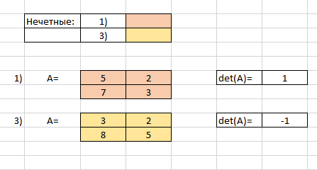

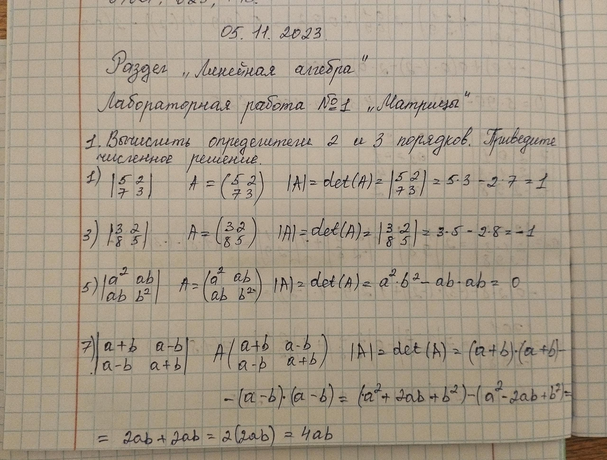

1. Распечатать нулевую матрицу 1) 1) размером 9x9 3) 3) размером 7x7 5) 5) размером 5x5 7) 7) размером 3x3

```python
import numpy as np

matrix1 = [[0 for _ in range(9)] for _ in range(9)]
print("Нулевая матрица 9x9:")
for row in matrix1:
    print(row)
matrix3 = [[0 for _ in range(7)] for _ in range(7)]
print("\nНулевая матрица 7x7:")
for row in matrix3:
    print(row)
matrix5 = [[0 for _ in range(5)] for _ in range(5)]
print("\nНулевая матрица 5x5:")
for row in matrix5:
    print(row)
matrix7 = [[0 for _ in range(3)] for _ in range(3)]
print("\nНулевая матрица 3x3:")
for row in matrix7:
    print(row)
```

```
Нулевая матрица 9x9:
[0, 0, 0, 0, 0, 0, 0, 0, 0]
[0, 0, 0, 0, 0, 0, 0, 0, 0]
[0, 0, 0, 0, 0, 0, 0, 0, 0]
[0, 0, 0, 0, 0, 0, 0, 0, 0]
[0, 0, 0, 0, 0, 0, 0, 0, 0]
[0, 0, 0, 0, 0, 0, 0, 0, 0]
[0, 0, 0, 0, 0, 0, 0, 0, 0]
[0, 0, 0, 0, 0, 0, 0, 0, 0]
[0, 0, 0, 0, 0, 0, 0, 0, 0]

Нулевая матрица 7x7:
[0, 0, 0, 0, 0, 0, 0]
[0, 0, 0, 0, 0, 0, 0]
[0, 0, 0, 0, 0, 0, 0]
```

[output cut: 16 more lines]

1. Распечатать вектор-строку 1) V1 = (1 2 3 4 5 6 7 8 9 10) 3) V3 = (10 100 1000 10000 100000)

```python
import numpy as np

V1 = np.array([1, 2, 3, 4, 5, 6, 7, 8, 9, 10])
print("V1 =", V1)

V3 = np.array([10, 100, 1000, 10000, 100000])
print("V3 =", V3)
```

```
V1 = [ 1  2  3  4  5  6  7  8  9 10]
V3 = [    10    100   1000  10000 100000]
```

1. Дан массив  
   А = (2 -1 2), В = (-1 0 5), С = (1 4 3)

Найти:  
1) 2А; 3) А + В - С

```python
import numpy as np

# Определение векторов A, B и C
A = np.array([2, -1, 2])
B = np.array([-1, 0, 5])
C = np.array([1, 4, 3])

result1 = 2 * A
print("1) 2A =", result1)

result3 = A + B - C
print("3) A + B - C =", result3)
```

```
1) 2A = [ 4 -2  4]
3) A + B - C = [ 0 -5  4]
```

1. Распечатать нулевую- вектор строку размера (zeros()) 1) 1)[0. 0. 0. 0. 0.] 3) 3)[0. 0. 0. 0. 0. 0. 0.]

```python
import numpy as np

vector1 = np.zeros(5)
print("1)", vector1)

vector3 = np.zeros(7)
print("3)", vector3)
```

```
1) [0. 0. 0. 0. 0.]
3) [0. 0. 0. 0. 0. 0. 0.]
```

1. Вывести на экран нулевой вектор (zeros()) А =

   0 0 0 0 0 0 0 0 0

```python
import numpy as np

A = np.zeros((3, 3))
print("A =")
print(A)
```

```
A =
[[0. 0. 0.]
 [0. 0. 0.]
 [0. 0. 0.]]
```

1. Вывести на экран вектор-столбец:

1) 10 20 30

3) 100 200 300

5) 2 2 2

```python
import numpy as np

vector1 = np.array([10, 20, 30]).reshape(-1, 1)
vector3 = np.array([100, 200, 300]).reshape(-1, 1)
vector5 = np.array([2, 2, 2]).reshape(-1, 1)

print("1)")
print(vector1)

print("\n3)")
print(vector3)

print("\n5)")
print(vector5)
```

```
1)
[[10]
 [20]
 [30]]

3)
[[100]
 [200]
 [300]]

5)
[[2]
 [2]
 [2]]
```

1. Построить единичную вектор-строку вида: 1) 1) [1. 1. 1.]

3) 3) [1. 1. 1. 1. 1.]

5) 5) [1. 1. 1. 1. 1. 1. 1. 1.]

```python
import numpy as np

vector1 = np.ones(3)
print("Единичная вектор-строка [1. 1. 1.]:")
print(vector1)

vector3 = np.ones(5)
print("\nЕдиничная вектор-строка [1. 1. 1. 1. 1.]:")
print(vector3)

vector5 = np.ones(8)
print("\nЕдиничная вектор-строка [1. 1. 1. 1. 1. 1. 1. 1.]:")
print(vector5)
```

```
Единичная вектор-строка [1. 1. 1.]:
[1. 1. 1.]

Единичная вектор-строка [1. 1. 1. 1. 1.]:
[1. 1. 1. 1. 1.]

Единичная вектор-строка [1. 1. 1. 1. 1. 1. 1. 1.]:
[1. 1. 1. 1. 1. 1. 1. 1.]
```

9) Вывести на экран единичный вектор-столбец размером:

1. 1x2, 2x1, 3x1, 4x1, 5x1, 6x1, 7x1, 8x1, 9x1
2. 1x3, 2x3, 3x3, 4x3, 5x3, 6x3, 7x3, 8x3, 9x3
3. 1x5, 2x5, 3x5, 4x5, 5x5, 6x5, 7x5, 8x5, 9x5

```python
# 9_____1----1x2, 2x1, 3x1, 4x1, 5x1, 6x1, 7x1, 8x1, 9x1

import numpy as np

# Создаем и выводим единичные векторы-столбцы
sizes = [1, 2, 3, 4, 5, 6, 7, 8, 9]
for size in sizes:
    vector = np.ones((size, 1))
    print(f"{size}x1")
    print(vector)
    print()
```

```
1x1
[[1.]]

2x1
[[1.]
 [1.]]

3x1
[[1.]
 [1.]
 [1.]]

4x1
[[1.]
 [1.]
 [1.]
 [1.]]

5x1
[[1.]
 [1.]
 [1.]
 [1.]
 [1.]]

6x1
[[1.]
 [1.]
 [1.]
 [1.]
 [1.]
 [1.]]

7x1
[[1.]
 [1.]
 [1.]
 [1.]
 [1.]
 [1.]
 [1.]]

8x1
[[1.]
 [1.]
 [1.]
 [1.]
 [1.]
 [1.]
 [1.]
 [1.]]

9x1
[[1.]
 [1.]
 [1.]
 [1.]
 [1.]
 [1.]
 [1.]
 [1.]
 [1.]]
```

```python
# 9_____3----1x3, 2x3, 3x3, 4x3, 5x3, 6x3, 7x3, 8x3, 9x3

import numpy as np

# Создаем и выводим единичные векторы-столбцы
sizes = [1, 2, 3, 4, 5, 6, 7, 8, 9]
for size in sizes:
    vector = np.ones((size, 3))
    print(f"{size}x3")
    print(vector)
    print()
```

```
1x3
[[1. 1. 1.]]

2x3
[[1. 1. 1.]
 [1. 1. 1.]]

3x3
[[1. 1. 1.]
 [1. 1. 1.]
 [1. 1. 1.]]

4x3
[[1. 1. 1.]
 [1. 1. 1.]
 [1. 1. 1.]
 [1. 1. 1.]]

5x3
[[1. 1. 1.]
 [1. 1. 1.]
 [1. 1. 1.]
 [1. 1. 1.]
 [1. 1. 1.]]

6x3
[[1. 1. 1.]
 [1. 1. 1.]
 [1. 1. 1.]
 [1. 1. 1.]
 [1. 1. 1.]
 [1. 1. 1.]]

7x3
[[1. 1. 1.]
 [1. 1. 1.]
 [1. 1. 1.]
 [1. 1. 1.]
 [1. 1. 1.]
 [1. 1. 1.]
 [1. 1. 1.]]

8x3
[[1. 1. 1.]
 [1. 1. 1.]
 [1. 1. 1.]
 [1. 1. 1.]
 [1. 1. 1.]
 [1. 1. 1.]
 [1. 1. 1.]
 [1. 1. 1.]]

9x3
[[1. 1. 1.]
 [1. 1. 1.]
 [1. 1. 1.]
 [1. 1. 1.]
 [1. 1. 1.]
 [1. 1. 1.]
 [1. 1. 1.]
 [1. 1. 1.]
 [1. 1. 1.]]
```

```python
# 9_____3----1x5, 2x5, 3x5, 4x5, 5x5, 6x5, 7x5, 8x5, 9x5

import numpy as np

# Создаем и выводим единичные векторы-столбцы
sizes = [1, 2, 3, 4, 5, 6, 7, 8, 9]
for size in sizes:
    vector = np.ones((size, 5))
    print(f"{size}x5")
    print(vector)
    print()
```

```
1x5
[[1. 1. 1. 1. 1.]]

2x5
[[1. 1. 1. 1. 1.]
 [1. 1. 1. 1. 1.]]

3x5
[[1. 1. 1. 1. 1.]
 [1. 1. 1. 1. 1.]
 [1. 1. 1. 1. 1.]]

4x5
[[1. 1. 1. 1. 1.]
 [1. 1. 1. 1. 1.]
 [1. 1. 1. 1. 1.]
 [1. 1. 1. 1. 1.]]

5x5
[[1. 1. 1. 1. 1.]
 [1. 1. 1. 1. 1.]
 [1. 1. 1. 1. 1.]
 [1. 1. 1. 1. 1.]
 [1. 1. 1. 1. 1.]]

6x5
[[1. 1. 1. 1. 1.]
 [1. 1. 1. 1. 1.]
 [1. 1. 1. 1. 1.]
 [1. 1. 1. 1. 1.]
 [1. 1. 1. 1. 1.]
 [1. 1. 1. 1. 1.]]

7x5
[[1. 1. 1. 1. 1.]
 [1. 1. 1. 1. 1.]
 [1. 1. 1. 1. 1.]
 [1. 1. 1. 1. 1.]
 [1. 1. 1. 1. 1.]
 [1. 1. 1. 1. 1.]
 [1. 1. 1. 1. 1.]]

8x5
[[1. 1. 1. 1. 1.]
 [1. 1. 1. 1. 1.]
 [1. 1. 1. 1. 1.]
 [1. 1. 1. 1. 1.]
 [1. 1. 1. 1. 1.]
 [1. 1. 1. 1. 1.]
 [1. 1. 1. 1. 1.]
 [1. 1. 1. 1. 1.]]

9x5
[[1. 1. 1. 1. 1.]
 [1. 1. 1. 1. 1.]
 [1. 1. 1. 1. 1.]
 [1. 1. 1. 1. 1.]
 [1. 1. 1. 1. 1.]
 [1. 1. 1. 1. 1.]
 [1. 1. 1. 1. 1.]
 [1. 1. 1. 1. 1.]
 [1. 1. 1. 1. 1.]]
```

1. Построить нулевой вектор-столбец

```python
import numpy as np

# Создаем нулевой вектор-столбец размером 3x1
zeroVector = np.zeros((3, 1))
print(zeroVector)
```

```
[[0.]
 [0.]
 [0.]]
```

1. Транспонировать матрицу вида:

```
        1)                          3)                               4)
        |11 12 13|    ----          |5 10  15|      ----             |18 19 20|
        |14 15 16|    ----          |20 25 30|      ----             |21 22 23|
        |17 18 19|    ----          |35 40 45|      ----             |24 25 26|
```

```python
import numpy as np

matrix = np.array([[11, 12, 13],
                  [14, 15, 16],
                  [17, 18, 19]])

transposed_matrix = matrix.T
print("1) ")
print(transposed_matrix)

matrix = np.array([[5, 10, 15],
                  [20, 25, 30],
                  [35, 40, 45]])

transposed_matrix = np.transpose(matrix)
print("\n3)")
print(transposed_matrix)

matrix = np.array([[18, 19, 20],
                  [21, 22, 23],
                  [24, 25, 26]])

transposed_matrix = np.transpose(matrix)
print("\n5)")
print(transposed_matrix)
```

```
1)
[[11 14 17]
 [12 15 18]
 [13 16 19]]

3)
[[ 5 20 35]
 [10 25 40]
 [15 30 45]]

5)
[[18 21 24]
 [19 22 25]
 [20 23 26]]
```

1. Умножьте матрицы на число K = n ( где n = 1, 2, 3,... 10). Приведите численное решение умножения матрицы на число К.

```
    1) A =                  3) A =
    |2   4  6|              |1   1  2|
    |8  10 12|              |3   5  8|
    |14 16 18|              |13 21 34|
```

```python
import numpy as np

A = np.array([[2, 4, 6],
              [8, 10, 12],
              [14, 16, 18]])
K = 5
result_matrix = A * K
print("1)     K = 5")
print(result_matrix)

A = np.array([[1, 1, 2],
              [3, 5, 8],
              [13, 21, 34]])
K = 3
print("\n3)     K = 3")
result_matrix = A * K

print(result_matrix)
```

```
1)     K = 5
[[10 20 30]
 [40 50 60]
 [70 80 90]]

3)     K = 3
[[  3   3   6]
 [  9  15  24]
 [ 39  63 102]]
```

```
         1) А =                       В =
         |11 12 13|                   |10 2 7|
         |14 15 16|                   |2 5 6 |
         |17 18 19|                   |1 8 1 |

         3) C =                       D =
         |1 1 1|                      |19 19 19|
         |2 2 2|                      |28 28 28|
         |3 3 3|                      |37 37 37|
```

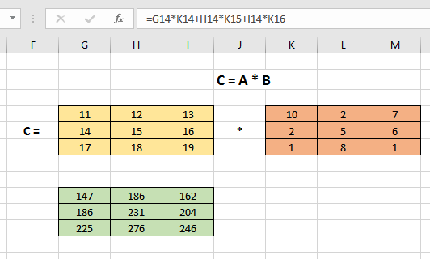

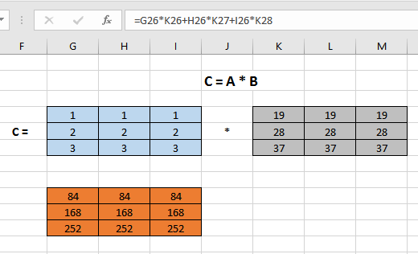

```python
import numpy as np

# Матрица А
A = np.array([[11, 12, 13],
              [14, 15, 16],
              [17, 18, 19]])

# Матрица В
B = np.array([[10, 2, 7],
              [2, 5, 6],
              [1, 8, 1]])

# Умножение матриц
C = np.dot(A, B)

# Вывод результата
print("Результат умножения матриц А и В:")
print(C)

# Матрица Q
Q = np.array([[1, 1, 1],
              [2, 2, 2],
              [3, 3, 3]])

# Матрица W
W = np.array([[19, 19, 19],
              [28, 28, 28],
              [37, 37, 37]])

# Умножение матриц
E = np.dot(Q, W)

# Вывод результата
print("\nРезультат умножения матриц Q и W:")
print(E)
```

```
Результат умножения матриц А и В:
[[147 186 162]
 [186 231 204]
 [225 276 246]]

Результат умножения матриц Q и W:
[[ 84  84  84]
 [168 168 168]
 [252 252 252]]
```

1. Найти произведение матриц

   ```
                        C = A * B
   1) А =          В =       |     3)    А =               В =
   |1 2 4 5|       |1|       |           |1|               |2 4 9 6|
   |3 1 0 2|       |4|       |           |0|
                   |8|       |           |7|
                   |9|       |           |8|
   ```

```python
import numpy as np

# Матрица A
A = np.array([[1, 2, 4, 5],
              [3, 1, 0, 2]])

# Матрица B
B = np.array([[1],
              [4],
              [8],
              [9]])

# Произведение матриц
C = np.dot(A, B)

# Вывод результата
print("Результат произведения матрицы A на матрицу B:")
print(C)

# Матрица А
A = np.array([[1],
              [0],
              [7],
              [8]])

# Матрица В
B = np.array([[2, 4, 9, 6]])

# Произведение матриц
C = np.dot(A, B)

# Вывод результата
print("\nРезультат произведения матриц А и В:")
print(C)
```

```
Результат произведения матрицы A на матрицу B:
[[86]
 [25]]

Результат произведения матриц А и В:
[[ 2  4  9  6]
 [ 0  0  0  0]
 [14 28 63 42]
 [16 32 72 48]]
```

1. Даны матрицы:

   ```
           |4 5|         |1 -1|
       A = |6 1|     B = |2 -3|
           |2 3|         |3 -2|
   ```

   Найти 2А – 3В

```python
import numpy as np

A = np.array([[4, 5], [6, 1], [2, 3]])
B = np.array([[1, -1], [2, -3], [3, -2]])

resultA = 2 * A
resultB = 3 * B
result = resultA - resultB
result
```

```
array([[ 5, 13],
       [ 6, 11],
       [-5, 12]])
```

[figure not shown]

1. Найти матрицу, транспонированную по отношению к матрице:

   ```
              A = (1 2 3), B =| 4 -5 6 |        C = |1 -3|
                              | 7 -8 2 |   ,        |2 -4|
   ```

```python
import numpy as np

A = np.array([[1, 2, 3]])
B = np.array([[4, -5, 6], [7, -8, 2]])
C = np.array([[1, -3], [2, -4]])

transposedA = np.transpose(A)
transposedB = np.transpose(B)
transposedC = np.transpose(C)

print("A =")
print(transposedA)
print("\nB =")
print(transposedB)
print("\nC =")
print(transposedC)
```

```
A =
[[1]
 [2]
 [3]]

B =
[[ 4  7]
 [-5 -8]
 [ 6  2]]

C =
[[ 1  2]
 [-3 -4]]
```

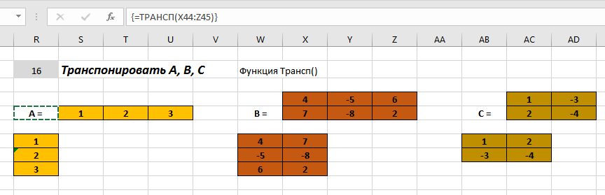